# CT genes analysis

```r
library("tidyverse")
library("CTexploreR")
library("ComplexHeatmap")
library("circlize")
library("SummarizedExperiment")
library("flextable")

set_flextable_defaults(
font.family = "Arial", font.size = 10,
border.color = "black",
padding = 6,
background.color = "#EFEFEF",
big.mark = "")
```

```r
legends_param <- list(
  labels_gp = gpar(col = "black", fontsize = 8),
  title_gp = gpar(col = "black", fontsize = 8, fontface = "bold"),
  simple_anno_size = unit(0.2, "cm"),
  row_names_gp = gpar(fontsize = 5),
  annotation_name_side = "left",
  border = FALSE,
  border_gp = gpar(lwd = 0.2),
  grid_width = unit(0.2, "cm"),
  grid_height = unit(0.05, "cm"),
  legend_height = unit(1, "cm"),
  use_raster = TRUE,
               raster_device = "CairoPNG",
               raster_quality = 10)

legend_colors <- c("#5E4FA2", "#3288BD", "#66C2A5", "#ABDDA4", "#E6F598",
"#FFFFBF", "#FEE08B", "#FDAE61", "#F46D43", "#D53E4F",
"#9E0142")

TCGA_colors <- c(
"BRCA" = "midnightblue", "COAD" = "darkorchid2",
"ESCA" = "gold", "HNSC" = "deeppink2",
"LUAD" = "seagreen", "LUSC" = "seagreen3",
"SKCM" = "red3")

CCLE_colors <- c(
"Lung" = "seagreen3", "Skin" = "red3",
"Bile_Duct" = "mediumpurple1", "Bladder" = "mistyrose2",
"Colorectal" = "plum", "Lymphoma" = "steelblue1",
"Uterine" = "darkorange4", "Myeloma" = "turquoise3",
"Kidney" = "thistle4",
"Pancreatic" = "darkmagenta", "Brain" = "palegreen2",
"Gastric" = "wheat3", "Breast" = "midnightblue",
"Bone" = "sienna1", "Head_and_Neck" = "deeppink2",
"Ovarian" = "tan3", "Sarcoma" = "lightcoral",
"Leukemia" = "steelblue4", "Esophageal" = "khaki",
"Neuroblastoma" = "olivedrab1")

DAC_colors <- c(
"B2-1" = "olivedrab2", "HCT116" = "lightcoral",
"HEK293T" = "seagreen3", "HMLER" = "mediumpurple1",
"IMR5-75" = "deeppink2", "NCH1681" = "steelblue2",
"NCH612" = "red3", "TS603" = "darkmagenta")

DAC_treatment_colors <- c("CTL" = "royalblue4", "5-aza" = "maroon3")

Regulation_colors <- c("Methylation" = "indianred2",
"Not methylation"= "cyan4")

MethDep_colors <- c("MethDep" = "indianred2",
"Non-MethDep"= "cyan4")

MethDep_full_name_colors <- c("MethDep CG gene" = "indianred2",
"Non-MethDep CG gene"= "cyan4")

Testis_specificity_colors = c("testis_specific" = "mediumpurple2",
"testis_preferential" = "goldenrod1",
"Undetectable in GTEX" = "gray")
```

# CT selection

## CT genes and CTP genes

```r
GTEX_data <- CTdata::GTEX_data()

#Function to print GTEX expression with specific annotations
print_GTEX_heatmap <- function(genes = NULL, units = "log_TPM",
                               row_fontsize = 2,
                               column_fontsize = 6,
                               h_width = 3,
                               h_height = 10,
                               clust_method = "ward.D",
                               clustRow = FALSE) {

  suppressMessages({
    database <- GTEX_data
  })

  database <- database[rowData(database)$external_gene_name %in% genes, ]

  mat <- assay(database)
  rownames(mat) <- rowData(database)$external_gene_name

  if (units == "log_TPM") mat <- log1p(mat)

  gene_type <- CT_genes %>%
    filter(external_gene_name %in% genes) %>%
    mutate(gene = factor(external_gene_name, levels = genes)) %>%
    arrange(gene)

   rowSplit <- gene_type$testis_specificity
   rowSplit[rowSplit == "testis_preferential"] <- "CG genes testis-preferential"
   rowSplit[rowSplit == "testis_specific"] <- "CG genes testis-specific"
   rowSplit <- factor(rowSplit, levels = c("CG genes testis-specific", "CG genes testis-preferential"))

  heatmap_colors <- colorRamp2(
    seq(0, 5, length = 11),
    legend_colors)

  h <- Heatmap(mat[as.vector(gene_type$gene), ],
               name = "log(TPM +1)",
               column_title = "Normal tissues (GTEx)",
               column_title_gp = gpar(fontsize = 8, face = "bold"),
               row_split = rowSplit,
               cluster_row_slices = FALSE,
               row_title_gp = gpar(fontsize = 8, face = "bold"),
               border = TRUE,
               border_gp = gpar(lwd = 0.5),
               col = heatmap_colors,
               cluster_rows = clustRow,
               cluster_columns = TRUE,
               show_row_dend = FALSE,
               show_column_dend = FALSE,
               row_names_gp = gpar(fontsize = row_fontsize),
               column_names_gp = gpar(fontsize = column_fontsize),
               column_names_side = "top",
               row_names_side = "left",
               width = unit(h_width, "cm"),
               height = unit(h_height, "cm"),
               clustering_method_rows = clust_method,
               use_raster = TRUE,
               raster_device = "CairoPNG",
               raster_quality = 10,
               heatmap_legend_param = legends_param)

  return(h)
}
```

```r
TCGA_TPM <- CTdata::TCGA_TPM()

# Function to print TCGA expression with specific annotations
# and to downsample the number of tumor samples per tumor type
print_TCGA_heatmap <- function(genes = NULL,
                               tum_type = c("TCGA-SKCM", "TCGA-LUAD",
                                            "TCGA-LUSC", "TCGA-COAD",
                                            "TCGA-BRCA", "TCGA-HNSC",
                                            "TCGA-ESCA"),
                               downsample_to_n = 450,
                               fontsize = 4,
                               clust_method = "ward.D",
                               h_width = 5,
                               h_height = 10,
                               show_annotation_legend = TRUE,
                               show_top_annotations = TRUE,
                               show_row_names = FALSE,
                               clustRow = FALSE,
                               clustCol = TRUE) {

  tcga <- TCGA_TPM
  tcga <- tcga[,tcga$shortLetterCode != "NT"]

  ## downsample tumors to have the same number of tumors in each type
  TCGA <- tcga[, tcga$project_id == tum_type[1]]
  TCGA <- TCGA[, 1:min(ncol(TCGA), downsample_to_n)]

  for (tum in tum_type[-1]){
    tmp <- tcga[, tcga$project_id == tum]
    tmp <- tmp[, 1:min(ncol(tmp), downsample_to_n)]
    TCGA <- cbind(TCGA, tmp)
  }

  TCGA$project_id <- gsub(pattern = "TCGA-", x = TCGA$project_id, replacement = '')
  split_by <- factor(TCGA$project_id)

  column_ha_tumor <- HeatmapAnnotation(
    TCGA_tumor = TCGA$project_id,
    border = TRUE,
    col = list(TCGA_tumor = TCGA_colors),
    annotation_label = gpar(fontsize = 4),
    annotation_name_gp = gpar(fontsize = 0),
    simple_anno_size = unit(0.3, "cm"),
    annotation_legend_param = legends_param)

  ## Use gene names instead of ENSEMBL IDs
  mat <- SummarizedExperiment::assay(TCGA)
  rownames(mat) <- rowData(TCGA)$external_gene_name
  mat <- log1p(mat)

  gene_type <- CT_genes %>%
    filter(external_gene_name %in% genes) %>%
    mutate(gene = factor(external_gene_name, levels = genes)) %>%
    arrange(gene)

   rowSplit <- gene_type$testis_specificity
   rowSplit[rowSplit == "testis_preferential"] <- "CG genes testis-preferential"
   rowSplit[rowSplit == "testis_specific"] <- "CG genes testis-specific"
   rowSplit <- factor(rowSplit, levels = c("CG genes testis-specific", "CG genes testis-preferential"))

  # same range as in GTEX
  heatmap_colors <- colorRamp2(
    seq(0, 5, length = 11),
    legend_colors)

  tAnnot <- NULL
  if (show_top_annotations) tAnnot <- column_ha_tumor

  Heatmap(mat[as.vector(gene_type$gene), ],
          name = "TCGA (logTPM)",
          column_title = "TCGA tumor samples",
          column_title_gp = gpar(fontsize = 8, face = "bold"),
          clustering_method_rows = clust_method,
          clustering_method_columns = clust_method,
          column_split = split_by,
          row_gap = unit(c(1), "mm"),
          col = heatmap_colors,
          cluster_rows = clustRow,
          cluster_columns = clustCol,
          show_row_names = show_row_names,
          show_column_names = FALSE,
          show_row_dend = FALSE,
          show_column_dend = FALSE,
          column_names_gp = gpar(fontsize = 6),
          column_names_centered = TRUE,
          row_names_gp = gpar(fontsize = fontsize),
          row_names_side = "left",
          border = TRUE,
          border_gp = gpar(lwd = 0.5),
          column_names_side = c("top"),
          column_names_rot = 90,
          row_title_gp = gpar(fontsize = 0),
          top_annotation = tAnnot,
          row_split = rowSplit,
          cluster_row_slices = FALSE,
          width = unit(h_width, "cm"),
          height = unit(h_height, "cm"),
          use_raster = TRUE,
          raster_device = "CairoPNG",
          raster_quality = 10,
          heatmap_legend_param = legends_param,
          show_heatmap_legend = FALSE)
}
```

```r
CCLE_data <- CTdata::CCLE_data()

# Function to print CCLE expression with specific annotations
# Allows to downsample the number of tumor samples pet tumor type to show
print_CCLE_heatmap <- function(genes = NULL,
                               Cellosaurus_NCIt_disease =
                                 c("Melanoma", "Lung adenocarcinoma"),
                               h_width = 5,
                               h_height = 10,
                               downsample_to_n = 450,
                               fontsize = 4,
                               clust_method = "ward.D",
                               split_rows_by = "regulation",
                               show_annotation_legend = TRUE,
                               clustRow = FALSE,
                               clustCol = TRUE){

  ## downsample tumors to have the same number of tumors in each type
  ccle <- CCLE_data
  CCLE <- ccle[, !is.na(ccle$Cellosaurus_NCIt_disease) &
                 ccle$Cellosaurus_NCIt_disease == Cellosaurus_NCIt_disease[1]]
  CCLE <- CCLE[, 1:min(ncol(CCLE), downsample_to_n)]

  for (tum in Cellosaurus_NCIt_disease[-1]){
    tmp <- ccle[, !is.na(ccle$Cellosaurus_NCIt_disease) &
                 ccle$Cellosaurus_NCIt_disease == tum]
    tmp <- tmp[, 1:min(ncol(tmp), downsample_to_n)]
    CCLE <- cbind(CCLE, tmp)
  }

  split_by <- factor(CCLE$Cellosaurus_NCIt_disease)

  column_ha_tumor <- HeatmapAnnotation(
    CCLE_cell_type = CCLE$Cellosaurus_NCIt_disease,
    border = TRUE,
    col = list(CCLE_cell_type = c(
      "Lung adenocarcinoma" = "seagreen", "Melanoma" = "red3")),
      annotation_label = gpar(fontsize = 4),
      annotation_name_gp = gpar(fontsize = 0),
      simple_anno_size = unit(0.3, "cm"),
      annotation_legend_param = legends_param)

  ## Use gene names instead of ENSEMBL IDs
  mat <- SummarizedExperiment::assay(CCLE)
  rownames(mat) <- rowData(CCLE)$external_gene_name
  mat <- log1p(mat)

   gene_type <- CT_genes %>%
    filter(external_gene_name %in% genes) %>%
    mutate(gene = factor(external_gene_name, levels = genes)) %>%
    arrange(gene)


   rowSplit <- gene_type$testis_specificity
   rowSplit[rowSplit == "testis_preferential"] <- "CG genes testis-preferential"
   rowSplit[rowSplit == "testis_specific"] <- "CG genes testis-specific"
   rowSplit <- factor(rowSplit, levels = c("CG genes testis-specific", "CG genes testis-preferential"))

    # Same range as GTEX and TCGA
  heatmap_colors <- colorRamp2(
    seq(0, 5, length = 11),
    legend_colors)

  Heatmap(mat[as.vector(gene_type$gene), ],
          name = "CCLE (logTPM)",
          column_title = paste0("CCLE tumor cell lines"),
          column_title_gp = gpar(fontsize = 8, face = "bold"),
          clustering_method_rows = clust_method,
          clustering_method_columns = clust_method,
          column_split = split_by,
          row_gap = unit(c(1), "mm"),
          col = heatmap_colors,
          cluster_rows = clustRow,
          cluster_columns = clustCol,
          show_row_names = TRUE,
          show_column_names = FALSE,
          show_row_dend = FALSE,
          show_column_dend = FALSE,
          column_names_gp = gpar(fontsize = 6),
          column_names_centered = TRUE,
          row_names_gp = gpar(fontsize = fontsize),
          row_names_side = "left",
          border = TRUE,
          border_gp = gpar(lwd = 0.5),
          column_names_side = c("top"),
          column_names_rot = 90,
          row_title_gp = gpar(fontsize = 0),
          top_annotation = column_ha_tumor,
          #right_annotation = rAnnot,
          row_split = rowSplit,
          width = unit(h_width, "cm"),
          height = unit(h_width, "cm"),
          use_raster = TRUE,
          raster_device = "CairoPNG",
          raster_quality = 10,
          heatmap_legend_param = legends_param,
          show_heatmap_legend = FALSE)
}
```

Top panel = Testis specific genes

Bottom panel = Testis preferential genes

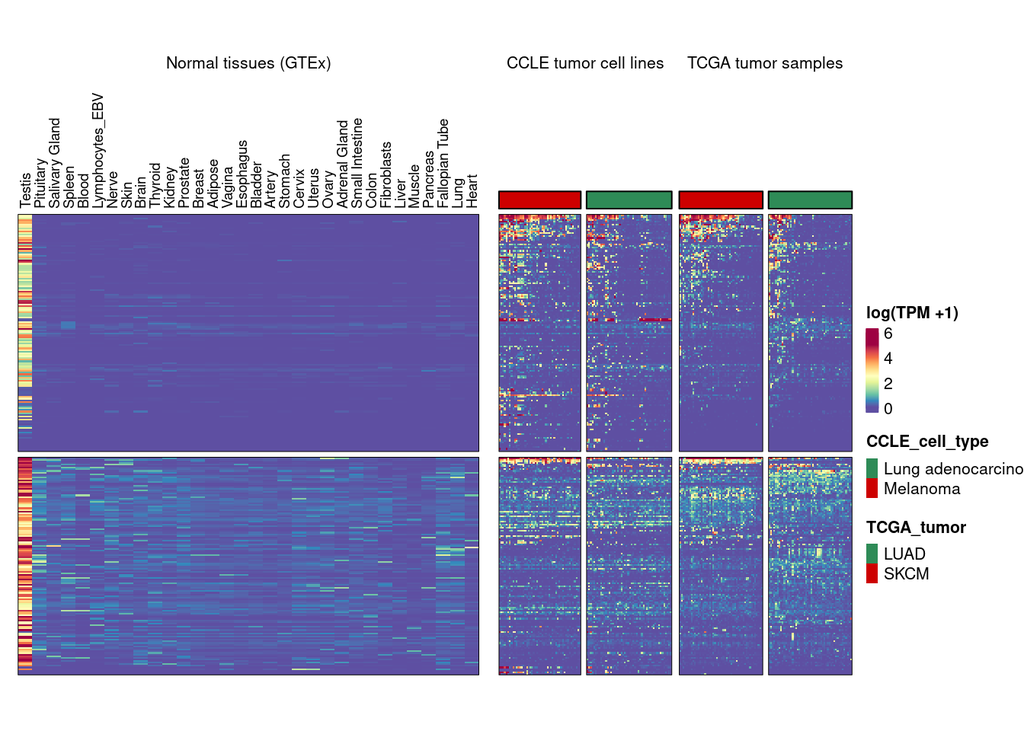

```r
my_genes <- CT_genes %>%
  pull(external_gene_name)

# Run the heatmap with custRow parameters to define the correct order
# This order will then be used for GTEX and CCLE heatmaps
ht_TCGA <- print_TCGA_heatmap(my_genes,
                              fontsize = 0,
                              downsample_to_n = 50,
                              h_width = 3,
                              h_height = 8,
                              tum_type = c("TCGA-SKCM", "TCGA-LUAD"),
                                           #"TCGA-ESCA", "TCGA-LUSC",
                                           #"TCGA-COAD",
                                           #"TCGA-BRCA",
                                           #"TCGA-HNSC"),
                              clust_method = "ward.D",
                              clustRow = TRUE)

indices <- row_order(ht_TCGA)
gene_order <- CT_genes %>%
  filter(external_gene_name %in% my_genes) %>%
  mutate(testis_specificity = factor(testis_specificity, levels = c("testis_specific", "testis_preferential"))) %>%
  arrange(testis_specificity) %>%
  pull(external_gene_name)

TS_order <- gene_order[indices$`CG genes testis-specific`]
TP_order <- gene_order[indices$`CG genes testis-preferential`]
my_genes <- c(TS_order, TP_order)

ht_TCGA <- print_TCGA_heatmap(my_genes,
                              fontsize = 4,
                              downsample_to_n = 50,
                              h_width = 3,
                              h_height = 8,
                              tum_type = c("TCGA-SKCM", "TCGA-LUAD"),
                                           #"TCGA-ESCA", "TCGA-LUSC",
                                           #"TCGA-COAD",
                                           #"TCGA-BRCA",
                                           #"TCGA-HNSC"),
                              clust_method = "ward.D",
                              show_annotation_legend = FALSE,
                              clustRow = FALSE)

ht_CCLE <- print_CCLE_heatmap(my_genes,
                              downsample_to_n = 50,
                               Cellosaurus_NCIt_disease =
                                c("Melanoma", "Lung adenocarcinoma"),
                              clustRow = FALSE,
                              show_annotation_legend = FALSE,
                              h_width = 3,
                              h_height = 8,
                              split_rows_by = "testis_specificity")


ht_GTEX <- print_GTEX_heatmap(my_genes,
                              row_fontsize = 0,
                              column_fontsize = 7,
                              h_width = 8,
                              h_height = 8,
                              clustRow = FALSE)

h_list <- ht_GTEX + ht_CCLE + ht_TCGA
fig <- draw(h_list, main_heatmap = "log(TPM +1)", ht_gap = unit(c(0.3, 0.03), "cm"),
     merge_legend = TRUE)
```

```r
pdf(file = paste0("../figs/CT_genes_selection.pdf"), width = 8, height = 5)
fig
dev.off()
```

## Figure Multimapping

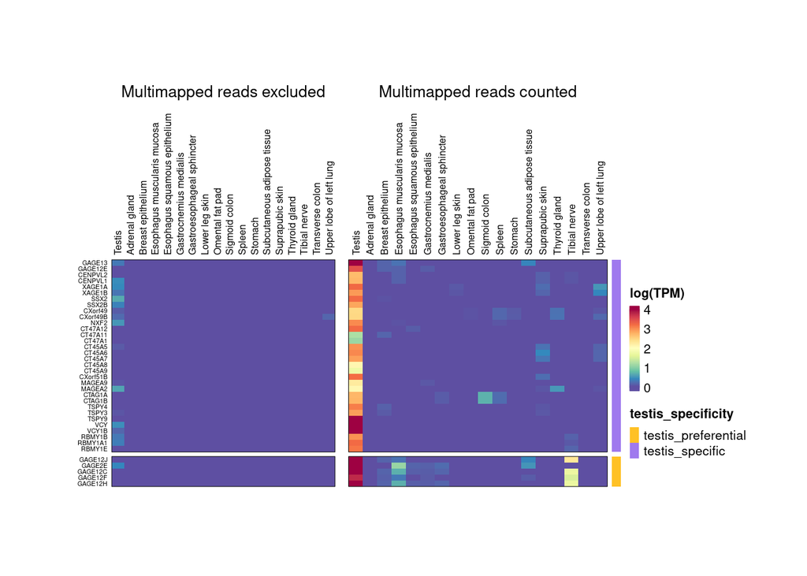

```r
normal_tissues_multimapping_data <- CTdata::normal_tissues_multimapping_data()

my_genes <- CT_genes %>%
  filter(GTEX_category == 'lowly_expressed')
my_genes$testis_specificity <- factor(my_genes$testis_specificity, levels = c("testis_specific", "testis_preferential"))
my_genes <- my_genes %>% arrange(testis_specificity)
rowSplit <- my_genes$testis_specificity

testis_specificity <- as.matrix(my_genes$testis_specificity)
rownames(testis_specificity) <- my_genes$gene
row_ha_TS <- rowAnnotation(testis_specificity = testis_specificity,
                           annotation_legend_param = legends_param,
                           simple_anno_size = unit(0.2, "cm"),
                           col = list(testis_specificity = Testis_specificity_colors),
                           annotation_name_gp = gpar(fontsize = 0))

without_MP <- log1p(
  assay(normal_tissues_multimapping_data[my_genes$ensembl_gene_id,],
    "TPM_no_multimapping"))
with_MP <-  log1p(
  assay(normal_tissues_multimapping_data[my_genes$ensembl_gene_id,],
    "TPM_with_multimapping"))
rownames(without_MP) <- rownames(with_MP) <-
  rowData(normal_tissues_multimapping_data)[my_genes$ensembl_gene_id,]$external_gene_name
# Fix same range of colors for both heatmaps
full_mat <- cbind(without_MP, with_MP)
heatmap_colors <- colorRamp2(
  seq(0, quantile(rowMax(full_mat), 0.8), length = 11), legend_colors)

# Or same range of colors than GTEX heatmap
# heatmap_colors <- colorRamp2(
#   seq(0, 6, length = 11), legend_colors)

colnames(without_MP) <- gsub("_", x = str_to_sentence(colnames(without_MP)), ' ')
colnames(with_MP) <- gsub("_", x = str_to_sentence(colnames(with_MP)), ' ')
ordered_tissues <-
  c("Testis", colnames(without_MP)[- which(colnames(without_MP) == "Testis")])
h_without_MP <- Heatmap(without_MP[my_genes$external_gene_name, ordered_tissues],
                        name = "no MP",
                        column_title = "Multimapped reads excluded",
                        column_title_gp = gpar(fontsize = 10, face = "bold"),
                        row_title_gp = gpar(fontsize = 0, face = "bold", angle  = 90),
                        row_split = rowSplit,
                        border = TRUE,
                        border_gp = gpar(lwd = 0.5),
                        col = heatmap_colors,
                        cluster_rows = FALSE,
                        cluster_columns = FALSE,
                        show_row_dend = FALSE,
                        show_column_dend = FALSE,
                        row_names_gp = gpar(fontsize = 4),
                        column_names_gp = gpar(fontsize = 6),
                        column_names_side = "top",
                        row_names_side = "left",
                        heatmap_width = unit(6, "cm"),
                        heatmap_height = unit(12, "cm"),
                        clustering_method_rows = "ward.D",
                        use_raster = TRUE,
                        raster_device = "CairoPNG",
                        raster_quality = 10,
                        show_heatmap_legend = FALSE,
                        heatmap_legend_param = legends_param)

h_with_MP <- Heatmap(with_MP[my_genes$external_gene_name, ordered_tissues],
                     name = "log(TPM)",
                     column_title = "Multimapped reads counted",
                     column_title_gp = gpar(fontsize = 10, face = "bold"),
                     row_title_gp = gpar(fontsize = 0, face = "bold"),
                     row_split = rowSplit,
                     border = TRUE,
                     border_gp = gpar(lwd = 0.5),
                     col = heatmap_colors,
                     cluster_rows = TRUE,
                     cluster_columns = FALSE,
                     show_row_dend = FALSE,
                     show_column_dend = FALSE,
                     row_names_gp = gpar(fontsize = 4),
                     column_names_gp = gpar(fontsize = 6),
                     column_names_side = "top",
                     row_names_side = "left",
                     heatmap_width = unit(6, "cm"),
                     heatmap_height = unit(12, "cm"),
                     clustering_method_rows = "ward.D",
                     right_annotation = c(row_ha_TS, gap = unit(1, "mm")),
                     use_raster = TRUE,
                     raster_device = "CairoPNG",
                     raster_quality = 10,
                     heatmap_legend_param = legends_param)

h_list <- h_without_MP + h_with_MP
draw(h_list, main_heatmap = "no MP", ht_gap = unit(0.3, "cm"),
                 height = unit(5, "cm"))
```

```r
pdf(file = paste0("../figs/FigS1_multimapping.pdf"))
draw(h_list, main_heatmap = "no MP", ht_gap = unit(0.3, "cm"),
                 height = unit(5, "cm"))
dev.off()
```

# Methylation analysis

```r
# Work only on testis_specific genes!
CT_genes <- CT_genes %>% filter(testis_specificity == "testis_specific")
```

## Fig3B

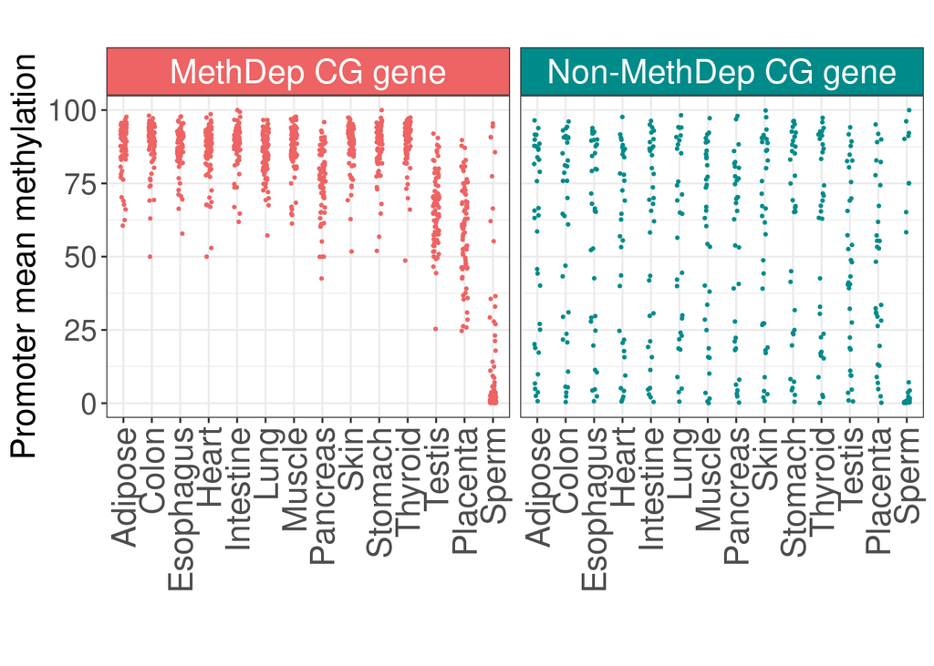

```r
mean_methylation_in_tissues <- CTdata::mean_methylation_in_tissues()

# Remove genes without enough methylation values for the figure
met_value_number_per_gene <- tibble(
  gene = CT_genes$external_gene_name,
  regulated_by_methylation = CT_genes$regulated_by_methylation,
  NA_met_values_number = rowSums(
    is.na(assay(mean_methylation_in_tissues[CT_genes$external_gene_name, ]))))
my_genes <- met_value_number_per_gene %>%
  arrange(desc(NA_met_values_number)) %>%
  filter(NA_met_values_number < 5) %>%
  pull(gene)

tissue_order <- c("adipose", "colon", "esophagus", "heart", "intestine",  "lung",
                  "muscle", "pancreas", "skin", "stomach",
                  "thyroid", "testis", "placenta", "sperm" )

database <- mean_methylation_in_tissues
rowData(database)$external_gene_name <- rownames(database)
database <- database[my_genes, ]
colnames(database) = str_to_sentence(colnames(database))
x <- as_tibble(assay(database), rownames = "gene") %>%
  pivot_longer(names_to = "tissue", values_to = "met", -gene) %>%
  left_join(CT_genes %>% dplyr::rename(gene = "external_gene_name")) %>%
  filter(CT_gene_type == "CT_gene") %>%
  filter(!is.na(regulated_by_methylation)) %>%
  mutate(tissue = factor(tissue, levels = str_to_sentence(tissue_order))) %>%
  mutate(group = case_when(regulated_by_methylation  ~"MethDep CG gene",
                           !regulated_by_methylation ~ "Non-MethDep CG gene"))

library(ggh4x)
strip <- strip_themed(background_x = elem_list_rect(fill = MethDep_colors))

figA <- x %>%
  ggplot(aes(x = tissue, y = met, color = group)) +
  geom_jitter(size = 0.5, width = 0.11) +
  scale_color_manual(values = MethDep_full_name_colors) +
  #geom_boxplot(alpha = 0) +
  #geom_violin(alpha = 0) +
  #facet_wrap(~ group, ncol = 2) +
  facet_grid2( ~ group ,  strip = strip) +
  theme_bw() +
  theme(axis.text.x = element_text(angle = 90, hjust = 1, vjust = 0.5, size = 18),
        axis.text.y = element_text(size = 16),
        aspect.ratio = 0.8,
        axis.title.y = element_text(size = 18),
        strip.text = element_text(size = 18, color = "white"),
        legend.position = "none") +
  ylab("Promoter mean methylation") +
  xlab("")

figA
```

```r
pdf(file = paste0("../figs/Fig3B_prom_methylation_in_tissues.pdf"))
figA
dev.off()
```

## Proportion of CT genes regulated by methylation

NB: One CT gene could not be classified as regulated or not by methylation

=> proportion based on 145/146 CT genes

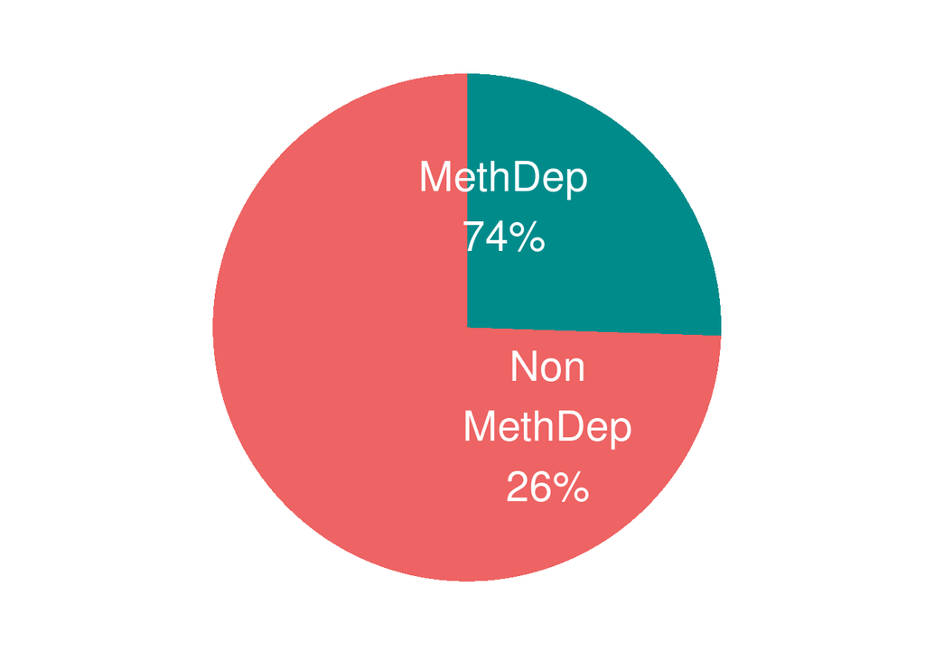

```r
x <- enframe(table(CT_genes %>%
  pull(regulated_by_methylation)), name = "Regulation") %>%
  left_join(enframe(prop.table(table(CT_genes$regulated_by_methylation)),
                    name = "Regulation", value = "Percent")) %>%
  mutate(group = case_when(Regulation == TRUE ~ "MethDep",
                           Regulation == FALSE ~ "Non\nMethDep"))


my_colors <- MethDep_colors
names(my_colors) <- c("MethDep","Non\nMethDep")
met_prop_fig <- ggplot(x, aes(x = '', y = value, fill = group)) +
  geom_bar(stat="identity", width=1) +
  coord_polar("y", start = 0) +
  geom_text(aes(y = value/5.5 + c(0, cumsum(value)[-length(value)]),
                label = rev(paste0(group, "\n",
                               round(Percent * 100), "%"))),
            size = 8,
            color = "white",
            face = "bold") +
            #, size = 6
  scale_fill_manual(values = my_colors) +
  theme(axis.title.x = element_blank(),
        axis.title.y = element_blank(),
        legend.title = element_blank(),
        panel.background = element_blank(),
        panel.border = element_blank(),
        panel.grid = element_blank(),
        axis.ticks = element_blank(),
        axis.text.x = element_blank(),
        legend.position = "none")


met_prop_fig
```

```r
pdf(file = paste0("../figs/Fig3A_proportion_of_CT_methylated.pdf"))
met_prop_fig
dev.off()
```

## Fig 3C: DAC heatmap

```r
DAC_treated_cells_multimapping <- CTdata::DAC_treated_cells_multimapping()
DAC_treated_cells <- CTdata::DAC_treated_cells()

DAC_fig <- function(genes = gene_type$gene,
                    multimapping = TRUE,
                    row_fontsize = 2,
                    units = "log1p",
                    values_only = FALSE,
                    scale_lims = NULL) {


  if (multimapping) {
    database <- CTdata::DAC_treated_cells_multimapping()
    #database <- DAC_treated_cells_multimapping

  } else {
    database <- CTdata::DAC_treated_cells()
  }

  database$treatment[database$treatment == "DAC"] <- "5-aza"
  database$treatment <- factor(database$treatment, levels = c("CTL", "5-aza"))
  gene_type <- CT_genes %>%
    filter(external_gene_name %in% genes)

  # sort genes regulated by met differently than not regulated by met
  gene_type_met <- gene_type %>%
    filter(regulated_by_methylation)

  gene_type_not_met <- gene_type %>%
    filter(!regulated_by_methylation) %>%
    arrange(germline_methylation, somatic_met_level)

  gene_type <- rbind(gene_type_met, gene_type_not_met)
  rownames(database) <- rowData(database)$external_gene_name

  gene_type <- gene_type %>%
    mutate(regulation = case_when(regulated_by_methylation == TRUE ~ "Methylation",
                                  regulated_by_methylation == FALSE ~ "Not Methylation")) %>%
    mutate(regulation = factor(regulation,
                                  levels = c("Methylation", "Not Methylation")))


  mat <- assay(database, units)

  df_col <- data.frame("cell" = colData(database)$cell,
                       "treatment" = colData(database)$treatment)
  rownames(df_col) <- rownames(colData(database))
  df_col <- df_col[order(df_col$cell, df_col$treatment), ]

  column_ha_cell <- HeatmapAnnotation(
    cell = df_col$cell,
    border = FALSE,
    #border_gp = gpar(lwd = 0.1),
    simple_anno_size = unit(0.2, "cm"),
    annotation_legend_param = legends_param,
    col = list("cell" = DAC_colors),
    annotation_name_gp = gpar(fontsize = 0))

  column_ha_treatment <- HeatmapAnnotation(
    treatment = df_col$treatment,
    col = list(treatment = c("CTL" = "dodgerblue3", "5-aza" = "firebrick1")),
    annotation_legend_param = legends_param,
    border = FALSE,
    simple_anno_size = unit(0.2, "cm"),
    annotation_name_gp = gpar(fontsize = 0))

  Regulation <- as.matrix(gene_type$regulated_by_methylation)
  rownames(Regulation) <- gene_type$gene
  row_ha_regulation <- rowAnnotation(Regulation = Regulation,
                                     annotation_legend_param = legends_param,
                                     simple_anno_size = unit(0.2, "cm"),
                                     col = list(Regulation = Regulation_colors),
                                     annotation_name_gp = gpar(fontsize = 0))


  if (is.null(scale_lims)) scale_lims <- c(0, quantile(rowMaxs(mat), 0.75))

  h <- Heatmap(mat[gene_type$external_gene_name, rownames(df_col), drop = FALSE],
               name = "logCounts",
               row_split = gene_type$regulation,
               left_annotation = rowAnnotation(
                       regulation = anno_block(
                         gp = gpar(fill = c(my_colors[1], my_colors[2]),
                                   col = "black", lwd = 0.1),
                         width = unit(c(0.5), "cm"),
                         labels = c("MethDep",
                                    "Non\nMethDep"),
                         labels_gp = gpar(col = "white", fontsize = 5, face = "bold"))),
               row_title_gp = gpar(col = my_colors, fontsize = 0),
               border = TRUE,
               border_gp = gpar(lwd = 0.2),
               column_title = "DAC induction in cell lines",
               column_title_gp = gpar(fontsize = 6),
               column_split = factor(df_col$cell),
               cluster_row_slices = FALSE,
               col = colorRamp2(seq(scale_lims[1], scale_lims[2], length = 11),
                                legend_colors),
               cluster_rows = TRUE,
               show_row_dend = FALSE,
               show_row_names = FALSE,
               clustering_method_rows = "ward.D",
               show_column_names = FALSE,
               cluster_columns = FALSE,
               row_names_gp = gpar(fontsize = row_fontsize),
               top_annotation = c(column_ha_cell, column_ha_treatment),
               heatmap_width = unit(4, "cm"),
               heatmap_height = unit(4, "cm"),
               use_raster = TRUE,
               raster_device = "CairoPNG",
               raster_quality = 10,
               heatmap_legend_param = legends_param)

  return(h)
}
```

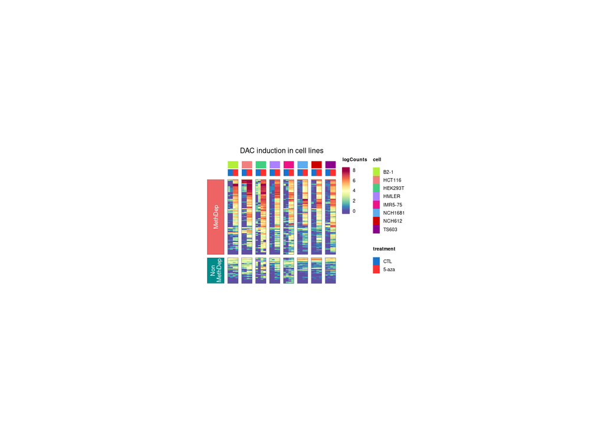

```r
legends_param <- list(
  labels_gp = gpar(col = "black", fontsize = 4),
  title_gp = gpar(col = "black", fontsize = 4, fontface = "bold"),
  simple_anno_size = unit(0.2, "cm"),
  row_names_gp = gpar(fontsize = 5),
  annotation_name_side = "left",
  border = FALSE,
  border_gp = gpar(lwd = 0.2),
  grid_width = unit(0.2, "cm"),
  grid_height = unit(0.05, "cm"),
  legend_height = unit(1, "cm"),
  use_raster = TRUE,
               raster_device = "CairoPNG",
               raster_quality = 10)


fs <- 1.8
my_genes <- CT_genes %>%
  filter(!is.na(DAC_induced))

h_DAC <- DAC_fig(my_genes$external_gene_name,
                 multimapping = TRUE,
                 units = "log1p",
                 row_fontsize = fs)

h_DAC
```

```r
pdf(file = paste0("../figs/Fig3C_methylation_classification.pdf"))
h_DAC
dev.off()
```

# CT genes regulated by met are enriched on X

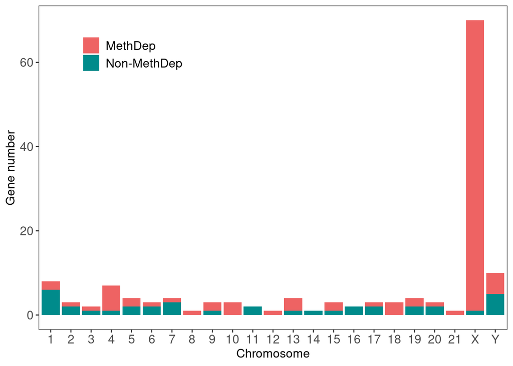

```r
CT_genes$chr <- factor(CT_genes$chr, levels = c(1:22, "X", "Y"))

fig_X_enrichment <- ggplot(CT_genes %>%
                             filter(!is.na(regulated_by_methylation)) %>%
  mutate(group = case_when(regulated_by_methylation == TRUE ~"MethDep",
                           regulated_by_methylation == FALSE ~ "Non-MethDep")),
                           aes(x = chr, fill = group)) +
  geom_bar(stat = 'count') +
  xlab("Chromosome") +
  ylab("Gene number") +
  scale_fill_manual(values = MethDep_colors)+
  theme_bw() +
  theme(legend.position = "inside",
        legend.position.inside = c(0.2, 0.85),
        legend.title = element_blank(),
        legend.text = element_text(size = 12),
        #aspect.ratio = .5,
        axis.title = element_text(size = 12),
        axis.text = element_text(size = 12),
        panel.grid = element_blank())

fig_X_enrichment
```

```r
pdf(file = paste0("../figs/Fig4A_enrichment_on_X.pdf"), height = 4, width = 6)
fig_X_enrichment
dev.off()
```

```r
CT_genes_X_linked <- CT_genes %>%
  mutate(Regulation = case_when(regulated_by_methylation == TRUE ~ "Methylation",
                                regulated_by_methylation == FALSE ~ "Not Methylation")) %>%
  mutate(Chr = case_when(X_linked ~ "X-linked",
                         !X_linked ~ "not X")) %>%
  filter(!is.na(regulated_by_methylation)) %>%
  group_by(Regulation, Chr) %>%
  dplyr::count() %>%
  pivot_wider(names_from = Regulation, values_from = n)

flextable(CT_genes_X_linked,
                     cwidth = 1.5,
                     cheight = 0.25) %>%
  set_caption(
    as_paragraph(
    as_chunk("CT genes", props = fp_text_default(font.family = "Arial",
                                                 font.size = 10))
    ), word_stylename = "Table Caption",
    align_with_table = TRUE
  )
```

CT genes

| Chr | Methylation | Not Methylation |
| --- | --- | --- |
| X-linked | 69 | 1 |
| not X | 39 | 36 |

```r
chisq.test(CT_genes_X_linked[,-1], correct = FALSE)
```

```
##
##  Pearson's Chi-squared test
##
## data:  CT_genes_X_linked[, -1]
## X-squared = 41.318, df = 1, p-value = 1.294e-10
```

idem but just comparing CT-X-linked to CT-autosomal

```r
CT_genes_X_linked <- CT_genes %>%
  mutate(Regulation = case_when(regulated_by_methylation == TRUE ~ "Methylation",
                                regulated_by_methylation == FALSE ~ "Not Methylation")) %>%
  mutate(Chr = case_when(chr == "X" ~ "X-linked",
                           chr == "Y" ~ "Y-linked",
                           !chr %in% c("X", "Y") ~ "Autosome")) %>%
  filter(!is.na(regulated_by_methylation)) %>%
  group_by(Regulation, Chr) %>%
  dplyr::count() %>%
  pivot_wider(names_from = Regulation, values_from = n)


flextable(CT_genes_X_linked,
                     cwidth = 1.5,
                     cheight = 0.25) %>%
  set_caption(
    as_paragraph(
    as_chunk("CT genes", props = fp_text_default(font.family = "Arial",
                                                 font.size = 10))
    ), word_stylename = "Table Caption",
    align_with_table = TRUE
  )
```

CT genes

| Chr | Methylation | Not Methylation |
| --- | --- | --- |
| Autosome | 34 | 31 |
| X-linked | 69 | 1 |
| Y-linked | 5 | 5 |

```r
chisq.test(CT_genes_X_linked[1:2, c("Methylation", "Not Methylation")], correct = FALSE)
```

```
##
##  Pearson's Chi-squared test
##
## data:  CT_genes_X_linked[1:2, c("Methylation", "Not Methylation")]
## X-squared = 39.888, df = 1, p-value = 2.69e-10
```

### Idem but normalised by number of gene per chromosome

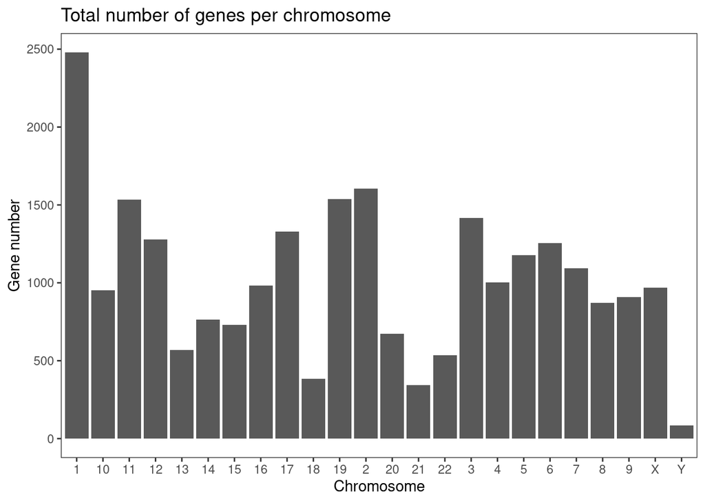

```r
n_genes_per_chr <- all_genes %>% filter(chr != "MT") %>%
  group_by(chr) %>%
  summarize(n = n()) %>%
  mutate(Chr = factor(chr, levels = c(1:22, "X", "Y"))) %>%
  arrange(Chr)

n_genes <- n_genes_per_chr %>%
  filter(!chr %in% "MT") %>%
  pull(n) %>% sum()
n_genes_autosome <- n_genes_per_chr %>%
  filter(chr %in% 1:22) %>%
  pull(n) %>% sum()
n_genes_X <- n_genes_per_chr %>%
  filter(chr %in% "X") %>%
  pull(n)
n_genes_Y <- n_genes_per_chr %>%
  filter(chr %in% "Y") %>%
  pull(n)

n_genes_per_chr_autosome_X_Y <- tibble("Chr" = c("Autosome", "X-linked", "Y-linked"),
       n = c(n_genes_autosome, n_genes_X, n_genes_Y))

ggplot(n_genes_per_chr, aes(x = chr, y = n)) +
  geom_col() +
  xlab("Chromosome") +
  ylab("Gene number") +
  scale_fill_manual(values = Regulation_colors) +
  theme_bw() +
  theme(legend.position = "inside",
        legend.position.inside = c(0.2, 0.85),
        #aspect.ratio = 1.5,
        panel.grid = element_blank()) +
  ggtitle("Total number of genes per chromosome")
```

```r
n_genes_per_chr_autosome_X_Y <- n_genes_per_chr_autosome_X_Y %>%
  mutate(proba = n / n_genes)
DT::datatable(n_genes_per_chr_autosome_X_Y)
```

|  | Chr | n | proba |
| --- | --- | --- | --- |
| 1 | Autosome | 23422 | 0.956976506639428 |
| 2 | X-linked | 968 | 0.03955056179775281 |
| 3 | Y-linked | 85 | 0.003472931562819203 |

```r
CT_genes_Met <- colSums(CT_genes_X_linked[, -1])["Methylation"]
CT_genes_not_Met <- colSums(CT_genes_X_linked[, -1])["Not Methylation"]


CT_genes_X_Y_observed_expected <- CT_genes_X_linked %>%
  left_join(n_genes_per_chr_autosome_X_Y %>% dplyr::select(-n)) %>%
  mutate(Expected_MET_if_random = (CT_genes_Met * proba),
         Expected_NOT_MET_if_random = (CT_genes_not_Met * proba)) %>%
  dplyr::select(Chr, Methylation, Expected_MET_if_random, `Not Methylation`, Expected_NOT_MET_if_random)

flextable(CT_genes_X_Y_observed_expected,
                     cwidth = 1.5,
                     cheight = 0.25) %>%
  set_caption(
    as_paragraph(
    as_chunk("CT genes", props = fp_text_default(font.family = "Arial",
                                                 font.size = 10))
    ), word_stylename = "Table Caption",
    align_with_table = TRUE
  )
```

CT genes

| Chr | Methylation | Expected_MET_if_random | Not Methylation | Expected_NOT_MET_if_random |
| --- | --- | --- | --- | --- |
| Autosome | 34 | 103.3534627 | 31 | 35.4081307 |
| X-linked | 69 | 4.2714607 | 1 | 1.4633708 |
| Y-linked | 5 | 0.3750766 | 5 | 0.1284985 |

**=> CT genes regulated by met are enriched on X when taking into account the number of genes per chromosome:**

```r
chisq.test(CT_genes_X_Y_observed_expected[
  CT_genes_X_Y_observed_expected$Chr %in% c("Autosome", "X-linked"), c("Methylation", "Expected_MET_if_random")], correct = FALSE)
```

```
##
##  Pearson's Chi-squared test
##
## data:  CT_genes_X_Y_observed_expected[CT_genes_X_Y_observed_expected$Chr %in%     c("Autosome", "X-linked"), c("Methylation", "Expected_MET_if_random")]
## X-squared = 92.143, df = 1, p-value < 2.2e-16
```

pvalue = 8.0635562^{-22}

```r
fisher.test(CT_genes_X_Y_observed_expected[
  CT_genes_X_Y_observed_expected$Chr %in% c("Autosome", "X-linked"), c("Methylation", "Expected_MET_if_random")])
```

```
##
##  Fisher's Exact Test for Count Data
##
## data:  CT_genes_X_Y_observed_expected[CT_genes_X_Y_observed_expected$Chr %in% c("Autosome", "X-linked"), c("Methylation", "Expected_MET_if_random")]
## p-value < 2.2e-16
## alternative hypothesis: true odds ratio is not equal to 1
## 95 percent confidence interval:
##  0.004817445 0.058043536
## sample estimates:
## odds ratio
## 0.01957843
```

pvalue = 2.2260817^{-24}

**=> But CT genes NOT regulated by met are NOT enriched on X when taking into account the number of genes per chromosome:**

```r
chisq.test(CT_genes_X_Y_observed_expected[
  CT_genes_X_Y_observed_expected$Chr %in% c("Autosome", "X-linked"), c("Not Methylation", "Expected_NOT_MET_if_random")], correct = FALSE)
```

```
##
##  Pearson's Chi-squared test
##
## data:  CT_genes_X_Y_observed_expected[CT_genes_X_Y_observed_expected$Chr %in%     c("Autosome", "X-linked"), c("Not Methylation", "Expected_NOT_MET_if_random")]
## X-squared = 0.035371, df = 1, p-value = 0.8508
```

```r
fisher.test(CT_genes_X_Y_observed_expected[
  CT_genes_X_Y_observed_expected$Chr %in% c("Autosome", "X-linked"), c("Not Methylation", "Expected_NOT_MET_if_random")])
```

```
##
##  Fisher's Exact Test for Count Data
##
## data:  CT_genes_X_Y_observed_expected[CT_genes_X_Y_observed_expected$Chr %in% c("Autosome", "X-linked"), c("Not Methylation", "Expected_NOT_MET_if_random")]
## p-value = 1
## alternative hypothesis: true odds ratio is not equal to 1
## 95 percent confidence interval:
##   0.01098178 71.70313511
## sample estimates:
## odds ratio
##  0.8873009
```

## CT genes are enriched among Testis-specific genes regulated by methylation

```r
all_genes_chr <- all_genes %>%
  mutate(chr = case_when(chr == "X" ~ "X-linked",
                           chr == "Y" ~ "Y-linked",
                           !chr %in% c("X", "Y") ~ "Autosome"))


TS_genes <- all_genes_chr %>%
  filter(testis_specificity == "testis_specific")
```

1476 Testis-specific genes (removing the 17 genes from the 1493 genes that could not be classified as regulated or not by methylation)

```r
prop_CT_among_TS <- TS_genes %>%
  filter(!is.na(regulated_by_methylation)) %>%
  mutate(Regulation = case_when(regulated_by_methylation ~ "Methylation",
                                !regulated_by_methylation ~ "Not Methylation")) %>%
 # mutate(Regulation = factor(Regulation, levels = c("Not Methylation", "Methylation"))) %>%
  mutate(`Testis-specific genes` = case_when(CT_gene_type == "CT_gene" ~ "CT gene",
                             CT_gene_type != "CT_gene" ~ "other")) %>%
  group_by(Regulation, `Testis-specific genes`) %>%
  dplyr::count() %>%
  pivot_wider(names_from = "Regulation", values_from = "n")


flextable(prop_CT_among_TS,
                     cwidth = 1.5,
                     cheight = 0.25)
```

| Testis-specific genes | Methylation | Not Methylation |
| --- | --- | --- |
| CT gene | 108 | 37 |
| other | 195 | 1136 |

```r
chisq.test(prop_CT_among_TS[,-1], correct = FALSE)
```

```
##
##  Pearson's Chi-squared test
##
## data:  prop_CT_among_TS[, -1]
## X-squared = 286.92, df = 1, p-value < 2.2e-16
```

**pvalue = 2.3319045^{-64}**

## Testis-specific genes (including CT genes) regulated by methylation are enriched on X

```r
TS_genes_X <- TS_genes %>%
  mutate(Regulation = case_when(regulated_by_methylation ~ "Methylation",
                                !regulated_by_methylation ~ "Not methylation")) %>%
  filter(!is.na(Regulation)) %>%
  #filter(chr != "Y-linked") %>%
  group_by(chr, Regulation) %>%
  dplyr::count() %>%
  pivot_wider(names_from = Regulation, values_from = "n")

flextable(TS_genes_X,
                     cwidth = 1.5,
                     cheight = 0.25) %>%
  set_caption(
    as_paragraph(
    as_chunk("Testis-specific genes", props = fp_text_default(font.family = "Arial",
                                                 font.size = 10))
    ), word_stylename = "Table Caption",
    align_with_table = TRUE
  )
```

Testis-specific genes

| chr | Methylation | Not methylation |
| --- | --- | --- |
| Autosome | 191 | 1117 |
| X-linked | 103 | 35 |
| Y-linked | 9 | 21 |

```r
TS_genes_X_Y <- TS_genes %>%
  mutate(Regulation = case_when(regulated_by_methylation ~ "Methylation",
                                !regulated_by_methylation ~ "Not methylation")) %>%
  filter(!is.na(Regulation)) %>%
  #filter(chr != "Y-linked") %>%
  group_by(chr, Regulation) %>%
  dplyr::count() %>%
  pivot_wider(names_from = Regulation, values_from = "n")

chisq.test(TS_genes_X_Y[TS_genes_X_Y$chr %in% c("Autosome", "X-linked"), c("Methylation", "Not methylation")], correct = FALSE)
```

```
##
##  Pearson's Chi-squared test
##
## data:  TS_genes_X_Y[TS_genes_X_Y$chr %in% c("Autosome", "X-linked"),     c("Methylation", "Not methylation")]
## X-squared = 277.76, df = 1, p-value < 2.2e-16
```

pvalue = 2.3121267^{-62}

**Idem but Normalised by number of gene per chromosome:**

```r
TS_genes_Met <- colSums(TS_genes_X_Y[, -1])["Methylation"]
TS_genes_not_Met <- colSums(TS_genes_X_Y[, -1])["Not methylation"]

TS_genes_X_Y_observed_expected <- TS_genes_X_Y %>%
  left_join(n_genes_per_chr_autosome_X_Y %>% dplyr::select(-n) %>% dplyr::rename(chr = Chr)) %>%
  mutate(Expected_MET_if_random = (TS_genes_Met * proba),
         Expected_NOT_MET_if_random = (TS_genes_not_Met * proba)) %>%
  dplyr::select(chr, Methylation, Expected_MET_if_random, `Not methylation`, Expected_NOT_MET_if_random)

flextable(TS_genes_X_Y_observed_expected,
                     cwidth = 1.5,
                     cheight = 0.25) %>%
  set_caption(
    as_paragraph(
    as_chunk("Testis-specific genes", props = fp_text_default(font.family = "Arial",
                                                 font.size = 10))
    ), word_stylename = "Table Caption",
    align_with_table = TRUE
  )
```

Testis-specific genes

| chr | Methylation | Expected_MET_if_random | Not methylation | Expected_NOT_MET_if_random |
| --- | --- | --- | --- | --- |
| Autosome | 191 | 289.963882 | 1117 | 1122.533442 |
| X-linked | 103 | 11.983820 | 35 | 46.392809 |
| Y-linked | 9 | 1.052298 | 21 | 4.073749 |

**=> Testis-specific genes regulated by methylation are significantly enriched on X when taking into account the number of genes per chromosome:**

```r
chisq.test(TS_genes_X_Y_observed_expected[
  TS_genes_X_Y_observed_expected$chr %in% c("Autosome", "X-linked"),
  c("Methylation", "Expected_MET_if_random")], correct = FALSE)
```

```
##
##  Pearson's Chi-squared test
##
## data:  TS_genes_X_Y_observed_expected[TS_genes_X_Y_observed_expected$chr %in%     c("Autosome", "X-linked"), c("Methylation", "Expected_MET_if_random")]
## X-squared = 92.318, df = 1, p-value < 2.2e-16
```

pvalue = 7.3816226^{-22})

**=> But testis-specific genes NOT regulated by methylation are not enriched on X when taking into account the number of genes per chromosome:**

```r
chisq.test(TS_genes_X_Y_observed_expected[
  TS_genes_X_Y_observed_expected$chr %in% c("Autosome", "X-linked"),
  c("Not methylation", "Expected_NOT_MET_if_random")], correct = FALSE)
```

```
##
##  Pearson's Chi-squared test
##
## data:  TS_genes_X_Y_observed_expected[TS_genes_X_Y_observed_expected$chr %in%     c("Autosome", "X-linked"), c("Not methylation", "Expected_NOT_MET_if_random")]
## X-squared = 1.485, df = 1, p-value = 0.223
```

pvalue = 0.2229943)

## Testis-specific genes (other than CT genes) regulated by methylation are also enriched on X

```r
TS_other_X <- TS_genes %>%
  mutate(Regulation = case_when(regulated_by_methylation ~ "Methylation",
                                !regulated_by_methylation ~ "Not methylation")) %>%
 filter(!is.na(Regulation)) %>%
  filter(CT_gene_type == "other") %>%
  #filter(chr != "Y-linked") %>%
  group_by(chr, Regulation) %>%
  dplyr::count() %>%
  pivot_wider(names_from = Regulation, values_from = "n")

TS_genes_other_Met <- colSums(TS_other_X[, -1])["Methylation"]
TS_genes_other_not_Met <- colSums(TS_other_X[, -1])["Not methylation"]

TS_other_X <- TS_other_X %>%
  left_join(n_genes_per_chr_autosome_X_Y %>% dplyr::select(-n) %>% dplyr::rename(chr = Chr)) %>%
  mutate(Expected_MET_if_random = (TS_genes_other_Met * proba),
         Expected_NOT_MET_if_random = (TS_genes_other_not_Met * proba)) %>%
  dplyr::select(chr, Methylation, Expected_MET_if_random, `Not methylation`, Expected_NOT_MET_if_random)

flextable(TS_other_X,
                     cwidth = 1.5,
                     cheight = 0.25) %>%
  set_caption(
    as_paragraph(
    as_chunk("Testis-specific genes (other than CT genes)", props = fp_text_default(font.family = "Arial",
                                                 font.size = 10))
    ), word_stylename = "Table Caption",
    align_with_table = TRUE
  )
```

Testis-specific genes (other than CT genes)

| chr | Methylation | Expected_MET_if_random | Not methylation | Expected_NOT_MET_if_random |
| --- | --- | --- | --- | --- |
| Autosome | 157 | 186.6104188 | 1086 | 1087.12531 |
| X-linked | 34 | 7.7123596 | 34 | 44.92944 |
| Y-linked | 4 | 0.6772217 | 16 | 3.94525 |

**=> Testis-specific genes (other than CT genes) regulated by methylation are also enriched on X:**

```r
chisq.test(TS_other_X[TS_other_X$chr %in% c("Autosome", "X-linked"),
                      c("Methylation", "Expected_MET_if_random")], correct = FALSE)
```

```
##
##  Pearson's Chi-squared test
##
## data:  TS_other_X[TS_other_X$chr %in% c("Autosome", "X-linked"), c("Methylation",     "Expected_MET_if_random")]
## X-squared = 19.091, df = 1, p-value = 1.246e-05
```

pvalue = 1.2461691^{-5}

```r
fisher.test(TS_other_X[TS_other_X$chr %in% c("Autosome", "X-linked"),
                      c("Methylation", "Expected_MET_if_random")])
```

```
##
##  Fisher's Exact Test for Count Data
##
## data:  TS_other_X[TS_other_X$chr %in% c("Autosome", "X-linked"), c("Methylation", "Expected_MET_if_random")]
## p-value = 1.307e-05
## alternative hypothesis: true odds ratio is not equal to 1
## 95 percent confidence interval:
##  0.07701235 0.45263710
## sample estimates:
## odds ratio
##   0.198307
```

pvalue = 1.3074041^{-5}

**=> Testis-specific genes (other than CT genes) NOT regulated by methylation are NOT enriched on X:**

```r
chisq.test(TS_other_X[TS_other_X$chr %in% c("Autosome", "X-linked"),
                      c("Not methylation", "Expected_NOT_MET_if_random")], correct = FALSE)
```

```
##
##  Pearson's Chi-squared test
##
## data:  TS_other_X[TS_other_X$chr %in% c("Autosome", "X-linked"), c("Not methylation",     "Expected_NOT_MET_if_random")]
## X-squared = 1.4495, df = 1, p-value = 0.2286
```